"Cardiotocography (CTG) is used during pregnancy to monitor fetal heart rate and uterine contractions. It is most commonly used in the third trimester and its purpose is to monitor fetal well-being and allow early detection of fetal distress. An abnormal CTG may indicate the need for further investigations and potential intervention" (Geekymedics 2020).  
To have fetus status is exremly important, normally, a pregnant woman start to do fetus health assessemnt after a period of 12 weeks pregnancy, base on the monitered features of a fetus, pediatrician can make better diagnosis.  
The dataset is classified by expert obstetricians,it is from faculty of Medicine,University of Porto, Portugal. There are 2126 fetal cardiotocograms included in this dataset.

[figure not shown]

Reference : https://geekymedics.com/how-to-read-a-ctg/ Dataset url: http://archive.ics.uci.edu/ml/datasets/Cardiotocography

# Feature Description:

[figure not shown]

# 1.Data Aquisiton

```python
import pandas as pd
df = pd.read_csv('./fetalHeartRate.csv')
df = df.drop(columns=['AC.1', 'FM.1', 'UC.1','DL.1', 'DS.1', 'DP.1'],axis=1)
df.shape #(2129, 35)
df.head(10)
```

|  | b | e | AC | FM | UC | DL | DS | DP | DR | LB | ... | B | C | D | E | AD | DE | LD | FS | SUSP | NSP |
| --- | --- | --- | --- | --- | --- | --- | --- | --- | --- | --- | --- | --- | --- | --- | --- | --- | --- | --- | --- | --- | --- |
| 0 | 240.0 | 357.0 | 0.0 | 0.0 | 0.0 | 0.0 | 0.0 | 0.0 | 0.0 | 120.0 | ... | -1.0 | -1.0 | -1.0 | -1.0 | -1.0 | -1.0 | -1.0 | 1.0 | -1.0 | 2.0 |
| 1 | 5.0 | 632.0 | 4.0 | 0.0 | 4.0 | 2.0 | 0.0 | 0.0 | 0.0 | 132.0 | ... | -1.0 | -1.0 | -1.0 | -1.0 | 1.0 | -1.0 | -1.0 | -1.0 | -1.0 | 1.0 |
| 2 | 177.0 | 779.0 | 2.0 | 0.0 | 5.0 | 2.0 | 0.0 | 0.0 | 0.0 | 133.0 | ... | -1.0 | -1.0 | -1.0 | -1.0 | 1.0 | -1.0 | -1.0 | -1.0 | -1.0 | 1.0 |
| 3 | 411.0 | 1192.0 | 2.0 | 0.0 | 6.0 | 2.0 | 0.0 | 0.0 | 0.0 | 134.0 | ... | -1.0 | -1.0 | -1.0 | -1.0 | 1.0 | -1.0 | -1.0 | -1.0 | -1.0 | 1.0 |
| 4 | 533.0 | 1147.0 | 4.0 | 0.0 | 5.0 | 0.0 | 0.0 | 0.0 | 0.0 | 132.0 | ... | 1.0 | -1.0 | -1.0 | -1.0 | -1.0 | -1.0 | -1.0 | -1.0 | -1.0 | 1.0 |
| 5 | 0.0 | 953.0 | 1.0 | 0.0 | 10.0 | 9.0 | 0.0 | 2.0 | 0.0 | 134.0 | ... | -1.0 | -1.0 | -1.0 | -1.0 | -1.0 | -1.0 | 1.0 | -1.0 | -1.0 | 3.0 |
| 6 | 240.0 | 953.0 | 1.0 | 0.0 | 9.0 | 6.0 | 0.0 | 2.0 | 0.0 | 134.0 | ... | -1.0 | -1.0 | -1.0 | -1.0 | -1.0 | -1.0 | 1.0 | -1.0 | -1.0 | 3.0 |
| 7 | 62.0 | 679.0 | 0.0 | 0.0 | 0.0 | 0.0 | 0.0 | 0.0 | 0.0 | 122.0 | ... | -1.0 | -1.0 | -1.0 | -1.0 | -1.0 | -1.0 | -1.0 | 1.0 | -1.0 | 3.0 |
| 8 | 120.0 | 779.0 | 0.0 | 0.0 | 1.0 | 0.0 | 0.0 | 0.0 | 0.0 | 122.0 | ... | -1.0 | -1.0 | -1.0 | -1.0 | -1.0 | -1.0 | -1.0 | 1.0 | -1.0 | 3.0 |
| 9 | 181.0 | 1192.0 | 0.0 | 0.0 | 3.0 | 0.0 | 0.0 | 0.0 | 0.0 | 122.0 | ... | -1.0 | -1.0 | -1.0 | -1.0 | -1.0 | -1.0 | -1.0 | 1.0 | -1.0 | 3.0 |

10 rows × 35 columns

# Data cleaning

1. Considering there are total 2129 simples, and the max number of null value in each column is 3, Direct remove the rows that contain null value won't affect result greatly.
2. Datatype: all float number, that is what we want. 3.Remove duplated rows. 4.Map -1 to 0 in columns "B C D E AD DE LD FS SUSP"

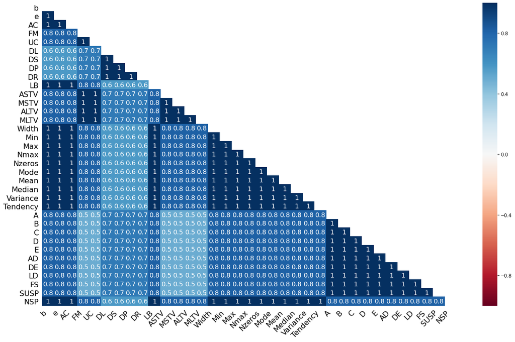

```python
import missingno as msno
msno.heatmap(df)
```

```python
miss_data_total = df.isnull().sum().sort_values(ascending=False)
df.isnull().count()
miss_data_per = (df.isnull().sum()/df.isnull().count()).sort_values(ascending=False)
miss_data = pd.concat([miss_data_total, miss_data_per], axis=1, keys=['Total', 'Percentage'])
df = df.dropna(axis=0,how='any')
df.shape # (2126, 41)
```

```
(2126, 35)
```

```python
df = df.drop_duplicates()
df.shape # (2116, 41)
df.head(5)
```

|  | b | e | AC | FM | UC | DL | DS | DP | DR | LB | ... | B | C | D | E | AD | DE | LD | FS | SUSP | NSP |
| --- | --- | --- | --- | --- | --- | --- | --- | --- | --- | --- | --- | --- | --- | --- | --- | --- | --- | --- | --- | --- | --- |
| 0 | 240.0 | 357.0 | 0.0 | 0.0 | 0.0 | 0.0 | 0.0 | 0.0 | 0.0 | 120.0 | ... | -1.0 | -1.0 | -1.0 | -1.0 | -1.0 | -1.0 | -1.0 | 1.0 | -1.0 | 2.0 |
| 1 | 5.0 | 632.0 | 4.0 | 0.0 | 4.0 | 2.0 | 0.0 | 0.0 | 0.0 | 132.0 | ... | -1.0 | -1.0 | -1.0 | -1.0 | 1.0 | -1.0 | -1.0 | -1.0 | -1.0 | 1.0 |
| 2 | 177.0 | 779.0 | 2.0 | 0.0 | 5.0 | 2.0 | 0.0 | 0.0 | 0.0 | 133.0 | ... | -1.0 | -1.0 | -1.0 | -1.0 | 1.0 | -1.0 | -1.0 | -1.0 | -1.0 | 1.0 |
| 3 | 411.0 | 1192.0 | 2.0 | 0.0 | 6.0 | 2.0 | 0.0 | 0.0 | 0.0 | 134.0 | ... | -1.0 | -1.0 | -1.0 | -1.0 | 1.0 | -1.0 | -1.0 | -1.0 | -1.0 | 1.0 |
| 4 | 533.0 | 1147.0 | 4.0 | 0.0 | 5.0 | 0.0 | 0.0 | 0.0 | 0.0 | 132.0 | ... | 1.0 | -1.0 | -1.0 | -1.0 | -1.0 | -1.0 | -1.0 | -1.0 | -1.0 | 1.0 |

5 rows × 35 columns

```python
df['B'].map({-1:0,1:1})
colums = ['B','C','D','E','AD','DE','LD','FS','SUSP']
for col in colums:
    df[col] = df[col].map({-1:0.0,1:1})
df[df.isnull()] = 0
df.head(5)
```

|  | b | e | AC | FM | UC | DL | DS | DP | DR | LB | ... | B | C | D | E | AD | DE | LD | FS | SUSP | NSP |
| --- | --- | --- | --- | --- | --- | --- | --- | --- | --- | --- | --- | --- | --- | --- | --- | --- | --- | --- | --- | --- | --- |
| 0 | 240.0 | 357.0 | 0.0 | 0.0 | 0.0 | 0.0 | 0.0 | 0.0 | 0.0 | 120.0 | ... | 0.0 | 0.0 | 0.0 | 0.0 | 0.0 | 0.0 | 0.0 | 1.0 | 0.0 | 2.0 |
| 1 | 5.0 | 632.0 | 4.0 | 0.0 | 4.0 | 2.0 | 0.0 | 0.0 | 0.0 | 132.0 | ... | 0.0 | 0.0 | 0.0 | 0.0 | 1.0 | 0.0 | 0.0 | 0.0 | 0.0 | 1.0 |
| 2 | 177.0 | 779.0 | 2.0 | 0.0 | 5.0 | 2.0 | 0.0 | 0.0 | 0.0 | 133.0 | ... | 0.0 | 0.0 | 0.0 | 0.0 | 1.0 | 0.0 | 0.0 | 0.0 | 0.0 | 1.0 |
| 3 | 411.0 | 1192.0 | 2.0 | 0.0 | 6.0 | 2.0 | 0.0 | 0.0 | 0.0 | 134.0 | ... | 0.0 | 0.0 | 0.0 | 0.0 | 1.0 | 0.0 | 0.0 | 0.0 | 0.0 | 1.0 |
| 4 | 533.0 | 1147.0 | 4.0 | 0.0 | 5.0 | 0.0 | 0.0 | 0.0 | 0.0 | 132.0 | ... | 1.0 | 0.0 | 0.0 | 0.0 | 0.0 | 0.0 | 0.0 | 0.0 | 0.0 | 1.0 |

5 rows × 35 columns

# Data preprocessing

1. Outliers detection.
2. Remove columns that contain mostly same value, it won't be significant to the result.
3. Remove error colums.

At here, we remove DR, which stands for repetitive decelerations, because most of numbers in this column are 0.  
Then we remove DS, which stands for severe decelerations, according to pediatrician, severe decelerations has no sifnificance when measuring the risk level of fetus, so here I remove it as well.

```python
df['DR'].value_counts() # 2116/2116 are 0 ， remove this column
df['DS'].value_counts() # 2109/2116 are 0, remove this colmun as well
df = df.drop(columns=['DR','DS'],axis=1)
df.shape #
```

```
(2116, 33)
```

### Checking Outliers manually

Fetal tachycardia is defined as a baseline heart rate greater than 160 bpm Fetal bradycardia is defined as a baseline heart rate of less than 100 bpm In this case, ther are no fetus suffers from both conditions.

```python
df.query('LB>160')
df.query('LB<100')
```

|  | b | e | AC | FM | UC | DL | DP | LB | ASTV | MSTV | ... | B | C | D | E | AD | DE | LD | FS | SUSP | NSP |
| --- | --- | --- | --- | --- | --- | --- | --- | --- | --- | --- | --- | --- | --- | --- | --- | --- | --- | --- | --- | --- | --- |

0 rows × 33 columns

# EDA

1.Baseline variability refers to the variation of fetal heart rate from one beat to the next. A healthy fetus baseline variability range from 5 to 25 bpm.  
Abnormal:  
less than 5 bpm for more than 50 minutes

[figure not shown]

There are no outliers in Baseline variability.

```python
Q1 = df["ASTV"].quantile(0.25)
Q3 = df["ASTV"].quantile(0.75)
IQR = Q3-Q1
lower = Q1 - 1.5*IQR
upper = Q3 + 1.5*IQR # 104
print(lower)
print(upper)
df.query('ASTV>104 or ASTV < 1')
```

```
-11.5
104.5
```

|  | b | e | AC | FM | UC | DL | DP | LB | ASTV | MSTV | ... | B | C | D | E | AD | DE | LD | FS | SUSP | NSP |
| --- | --- | --- | --- | --- | --- | --- | --- | --- | --- | --- | --- | --- | --- | --- | --- | --- | --- | --- | --- | --- | --- |

0 rows × 33 columns

[figure not shown]

For prolonged deceleration, If it lasts between 2-3 minutes it is classed as non-reassuring. If it lasts longer than 3 minutes it is immediately classed as abnormal. In this case, there are samples that prolonged deceleration are zero, it's impossible for fetus that have no heat beat deceleration. There are about 91% samples have 0 prolonged deceleration. Let's remove this column.

```python
df.query('DP>3') # 1 rows × 33 columns
cols = df.query('DP==0')['DP'].count()
# 1938 rows
rows = df.shape[0]
print(cols / rows) # 0.9158790170132325
df = df.drop(columns=['DP'],axis=1)
df.head(5)
```

```
0.9158790170132325
```

|  | b | e | AC | FM | UC | DL | LB | ASTV | MSTV | ALTV | ... | B | C | D | E | AD | DE | LD | FS | SUSP | NSP |
| --- | --- | --- | --- | --- | --- | --- | --- | --- | --- | --- | --- | --- | --- | --- | --- | --- | --- | --- | --- | --- | --- |
| 0 | 240.0 | 357.0 | 0.0 | 0.0 | 0.0 | 0.0 | 120.0 | 73.0 | 0.5 | 43.0 | ... | 0.0 | 0.0 | 0.0 | 0.0 | 0.0 | 0.0 | 0.0 | 1.0 | 0.0 | 2.0 |
| 1 | 5.0 | 632.0 | 4.0 | 0.0 | 4.0 | 2.0 | 132.0 | 17.0 | 2.1 | 0.0 | ... | 0.0 | 0.0 | 0.0 | 0.0 | 1.0 | 0.0 | 0.0 | 0.0 | 0.0 | 1.0 |
| 2 | 177.0 | 779.0 | 2.0 | 0.0 | 5.0 | 2.0 | 133.0 | 16.0 | 2.1 | 0.0 | ... | 0.0 | 0.0 | 0.0 | 0.0 | 1.0 | 0.0 | 0.0 | 0.0 | 0.0 | 1.0 |
| 3 | 411.0 | 1192.0 | 2.0 | 0.0 | 6.0 | 2.0 | 134.0 | 16.0 | 2.4 | 0.0 | ... | 0.0 | 0.0 | 0.0 | 0.0 | 1.0 | 0.0 | 0.0 | 0.0 | 0.0 | 1.0 |
| 4 | 533.0 | 1147.0 | 4.0 | 0.0 | 5.0 | 0.0 | 132.0 | 16.0 | 2.4 | 0.0 | ... | 1.0 | 0.0 | 0.0 | 0.0 | 0.0 | 0.0 | 0.0 | 0.0 | 0.0 | 1.0 |

5 rows × 32 columns

This is getting painful to select features manually as none domain expert,let me try to use other other way to do it.

```python
from sklearn.feature_selection import RFE
from sklearn.linear_model import LinearRegression
from sklearn.metrics import accuracy_score
import seaborn as sns
from sklearn import metrics
from sklearn.model_selection import train_test_split

def getRankedColumns(df):
    X = df.drop(columns = ['NSP']).values
    y = df['NSP'].values
    lr = LinearRegression()
    rfe = RFE(lr,n_features_to_select=1)
    rfe.fit(X,y)
    names = df.drop(columns = ['NSP']).columns
    print("Feature sorted by their rank:")
    list1 = sorted(zip(map(lambda x : round(x,4),rfe.ranking_),names))
    li = []
    for i in list1:
        li.append(i[1])
    print(li)
    return li

keepColums =getRankedColumns(df)
def scoreHeapMap(y_predict,y_test):
    score =accuracy_score(y_predict,y_test)
    cm = metrics.confusion_matrix(y_test,y_predict)
    plt.figure(figsize=(9,9))
    sns.heatmap(cm, annot=True, fmt=".3f", linewidths=.5, square = True, cmap = 'Blues');
    plt.ylabel('Actual RISK level');
    plt.xlabel('Predicted RISK level');
    all_sample_title = 'Accuracy Score: {0}'.format(score)
    plt.title(all_sample_title, size = 15);
def model_and_score(keepColums,df):
    X = df.drop(columns=['NSP'],axis=1)
    y = df['NSP']
    (X_train, X_test, y_train, y_test) = train_test_split(X, y, test_size=0.3, random_state=0)
    regre.fit(X_train,y_train)
    y_predict = regre.predict(X_test)
    scoreHeapMap(y_predict,y_test)
```

```
Feature sorted by their rank:
['LD', 'FS', 'D', 'C', 'B', 'AD', 'DE', 'A', 'SUSP', 'E', 'Nzeros', 'DL', 'Tendency', 'MSTV', 'Nmax', 'LB', 'Mean', 'ALTV', 'ASTV', 'Variance', 'Mode', 'UC', 'Width', 'FM', 'Max', 'AC', 'Median', 'MLTV', 'b', 'e', 'Min']
```

# MODELLING & Score

Let's try if model performs well after reduced the dimention. Out objective is to detect risk level of fetus, there are 3 level in total, each present diffirent degree of risks.  
So it's a classification problem, we can use LogisticRegression to solve the problem.

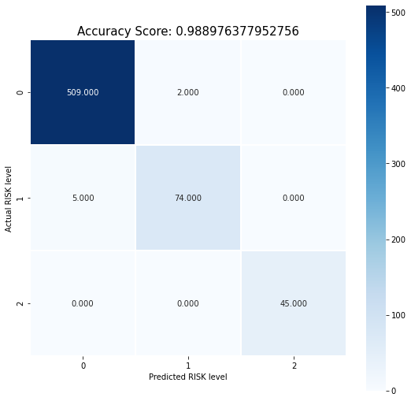

```python
model_and_score(keepColums,df)
```

With an acccuracy of 98%. This model will have a good chance of been overfitting.  
Let me reduce more columns

```
['LD', 'FS', 'D', 'C', 'B', 'AD', 'DE', 'A', 'SUSP', 'E', 'Nzeros', 'DL', 'Tendency', 'MSTV', 'Nmax']
```

[figure not shown]

```python
print(keepColums[:15])
model_and_score(keepColums[:15],df)
```

```
['LD', 'FS', 'D', 'C', 'B', 'AD', 'DE', 'A', 'SUSP', 'E']
```

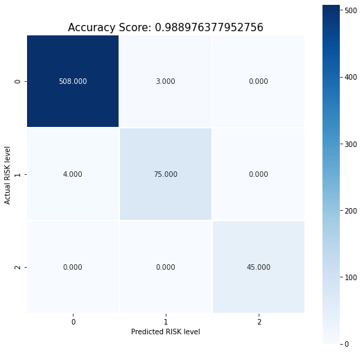

```python
print(keepColums[:10])
model_and_score(keepColums[:10],df)
```

### The model is still facing an overfitting problem

```python
import numpy as np

a = pd.Series (np.array([3,4,5]))
b = pd.Series(np.array([3,4,5,8,9]))
np.isin(b,a)

index = df[df['NSP'] == 1].index.tolist()
index = index [:100]

small = df.iloc[index,:]
# df[np.isin(df,small)].shape
df = pd.concat([small, df[df['NSP'] == 2], df[df['NSP'] == 3]]) # 568 rows × 32 columns
```

### Mess up the indices might help model perform better

```python
from sklearn.utils import shuffle
df = shuffle(df)
```

### Let's try agian

[output not shown]

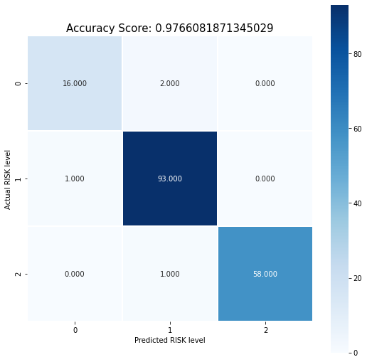

```python
model_and_score(keepColums[:10],df)
```